# Projet 4M074

Djerroud Santarsieri

19/04/2020

# Approximation de toute densité continue par un mélange gaussien

### Modèle de mélange gaussien

Un modèle de mélange gaussien est un modèle statistique exprimé par une densité de mélange. Il sert usuellement à estimer paramétriquement la distribution de variables aléatoires en les modélisant comme une somme de plusieurs gaussiennes.

### Le modèle

Le modèle de mélange fini de lois de probabilité consiste à supposer que les données proviennent d’une source contenant plusieurs sous-populations homogènes appelées composants. La population totale est un mélange de ces sous-populations. Le modèle résultant est un modèle de mélange fini.

Soit $X=(X_1,\dots,X_n)$ un échantillon de variables aléatoires indépendantes identiquement distribuées (iid ) de loi de mélange fini à $K$ composants, de densité f dont la forme générale est :
$$f(x)=\sum_{k=1}^{K}\pi_k h_{\Phi_k}(x)$$
avec:

- $\pi_k$ les proportions respectives des sous populations telle que $0<\pi_k\leq1$ et $\sum_{k=1}^{K}\pi_k=1$
- $h_{\Phi_k}$ la densité du k-ième composant (une gaussienne $\mathcal{N}(\mu_k,\sigma_k^2)$).

Le modèle de mélange est un modèle à données manquantes. En effet, si on échantillonnait dans une population formée par K sous-populations, on devrait avoir les couples $( X_i,Z_i)$, où $X_i=x_i$ indique la mesure faite sur le i-ème individu et $Z_i=k$ indique le numéro de la sous-population à laquelle appartient cet individu. En échantillonnant dans la sous population $k$ et en supposant $X$ discrète, on obtiendrait alors le modèle $\mathbb{P}( X =x|Z=k )= f_k( x ,\alpha_k)$. Mais le paramètre $\alpha_k$ est en général inconnu et propre à la k-ième sous-population. De même,les données manquantes sont $Z=(Z_1,\dots, Z_n)$,avec $Z_i=k$ si $i$ provient du groupe $k$.

On n’observe donc que l’échantillon $( X_1,\dots,X_n)$. Le mélange définit plus haut peut être vu comme la loi marginale de la variable $X$ pour le couple $(X , Z)$. C’est donc un modèle à données manquantes.

### Remarque:

**Toute densité continue peut s’approcher à l’aide d’un mélange gaussien, au sens de la norme $\ L_1$ ou uniformement sur tout compact.**

Cela s’appuie sur le théorème suivant:

### Théorème

Soit $g$ une densité continue. Pour tout $\varepsilon >0$ il existe un mélange gaussien fini de densité $\overline{g}$ donnée par :

$$\overline{g}=\sum_{j=1}^{m} \pi_jf_\mathcal{N(\mu_j,\sigma_j^2)}(x)$$
avec $\mu_j\in \mathbb{R}$, $\sigma_j >0$ tel que $\sum_{j=1}^{m}\pi_j=1$, tel que
$$\|g-\overline{g}\|_1:=\int_\mathbb{R} \ |\ g(x)-\overline{g}(x)|<\varepsilon$$

De même, pour tout $\varepsilon >0$ et tout compact $\kappa$, il existe un mélange gaussien fini de densité $\overline{g}$ tel que
$$\sup_{x\in \kappa} |\ g(x)-\overline{g}(x) |<\varepsilon$$

### Illustration du théorème

Ici, notre but sera d’illustrer graphiquement ce thèorème. On se restreindra aux densités continues usuelles: densité d’une loi gamma de paramètres $\ a$ et $\ b$ , $\Gamma\ (a,b)$, loi Beta $\ B \ (a,b)$, loi de Student $\ T \ (k)$ à $\ k$ degrés de liberté, loi du $\ X ^2 \ (k)$ et loi de Fisher $\ F \ (d_1,d_2)$.

On verra par la suite que toutes ces densités peuvent être approchées par des mélanges gaussiens à densité unimodale, parfois dyssimétrique ou fortement dyssimétrique, parfois par des densités avec outlier. Comment approcher donc ces densités? En reprenant la formule plus haut,
$$\overline{g}=\sum_{j=1}^{m} \pi_jf_\mathcal{N(\mu_j,\sigma_j^2)}(x)$$
on remarque que pour pouvoir déterminer notre mélange gaussien, on devra estimer le vecteur des paramètres $\theta = (\mu_1,...,\mu_m, \sigma_1^2,...,\sigma_m^2,\pi_1,...,\pi_m)$, $\ j \in \ [1,..m]$ Pour le faire, on a décidé d’utiliser l’algorithme EM (espérance-maximisation). Cet algorithme calcule par itération les paramètres de l’EMV en considérant l’esperance conditionnelle de la log-vraisemblance des données observées et le paramètre obtenu à l’itération précedente.

On a décidé d’utiliser cet algorithme à travers le package R *mixtools* (pour les 3 premiers exemples ) et l’algorithme EM vu en TP (pour les 2 derniers exemples ). Pour rendre notre illustration plus intéressante on a laissé à l’utilisateur le choix des paramètres suivants: - $\ n$: nombre d’observations qui vont être utilisées par l’algorithme -$\ d_1, \ d_2 , \ a, \ b$: paramètres des lois choisies - $\ l$: ordre du mélange

Passons maintenant à l’illustration pour les différentes lois:

#### Loi de Student $\mathcal{T}(df1)$

```
## number of iterations= 18
```

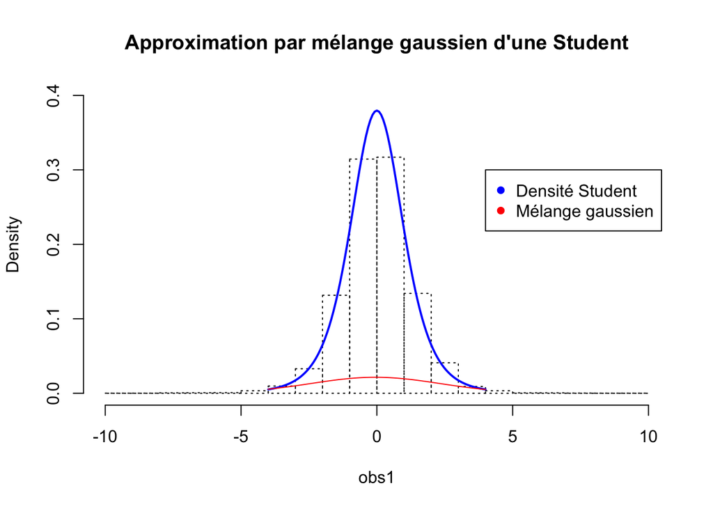

#### Loi du Chi 2 $\mathfrak{\chi}^2_{(d1)}$

On crée une fonction qui determine la densité d’une loi du Chi-2 et on dessine la courbe de la densité d’une loi du Chi-2 à 4 degrés de liberté.

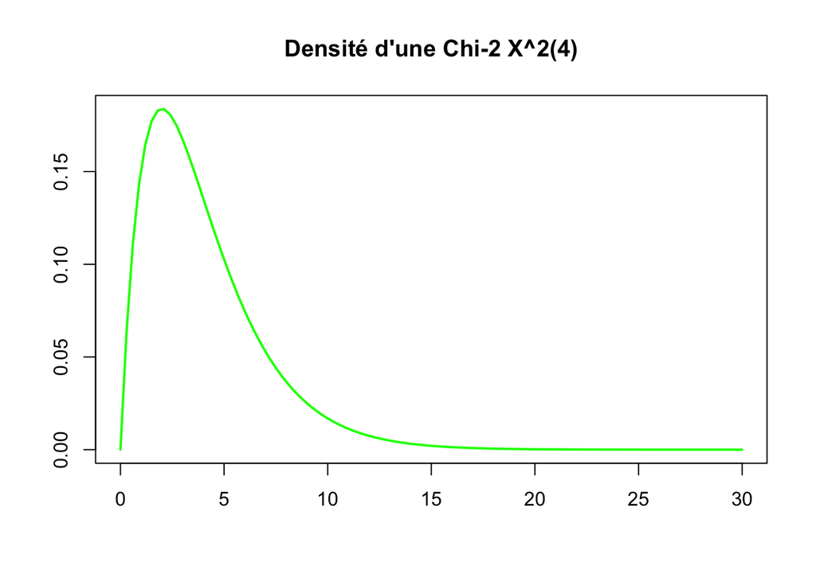

```
## number of iterations= 55
```

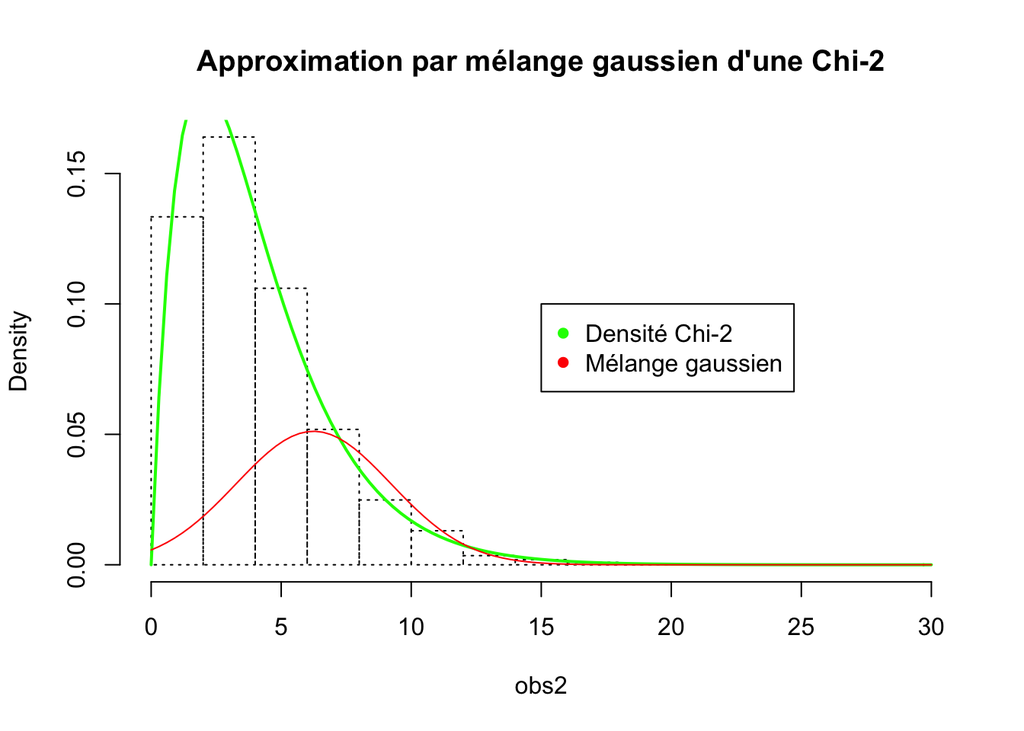

#### Loi de Fisher $\mathcal{F}^{d1}_{d2}$

On crée une fonction qui determine la densité d’une loi de Fisher et on dessine la courbe de la densité d’une loi de Fisher à 10,20 degrés de liberté.

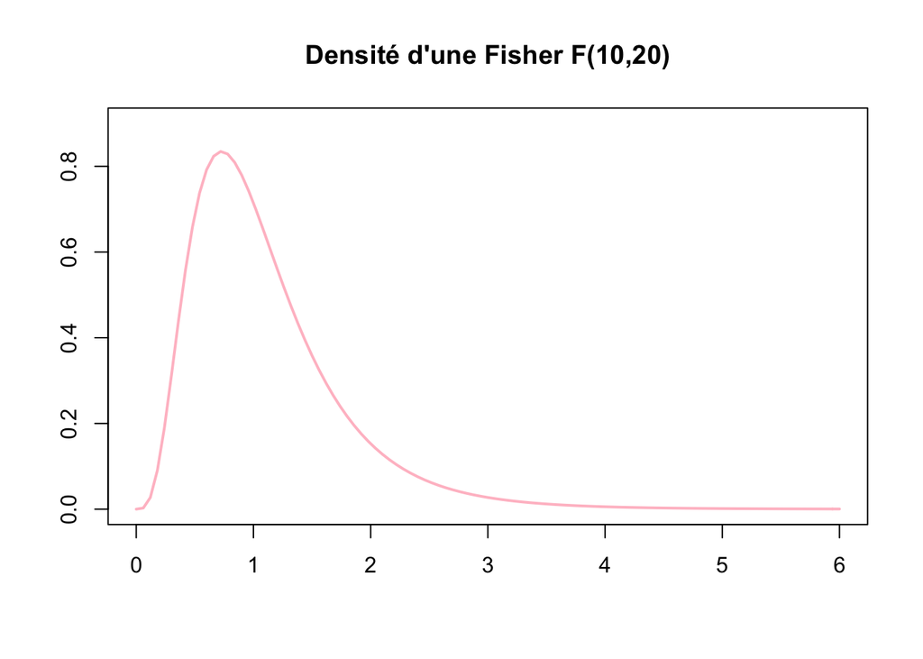

```
## number of iterations= 42
```

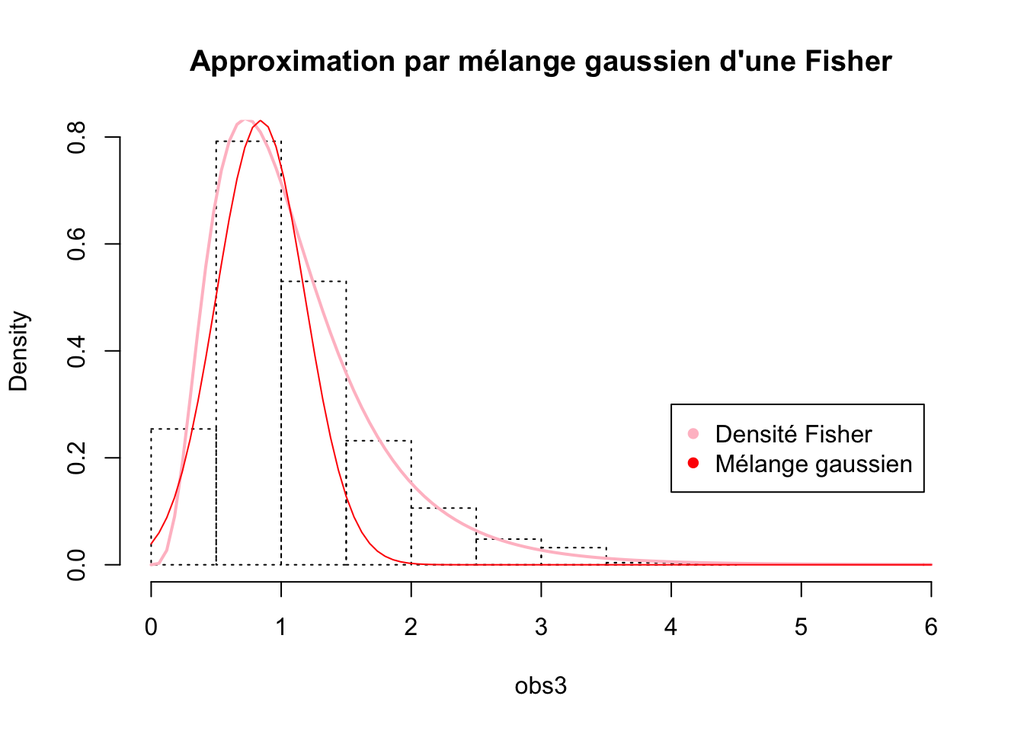

#### Loi Bêta

Dans cette partie on veut simuler la densité de la loi Beta par un mélange gaussien:

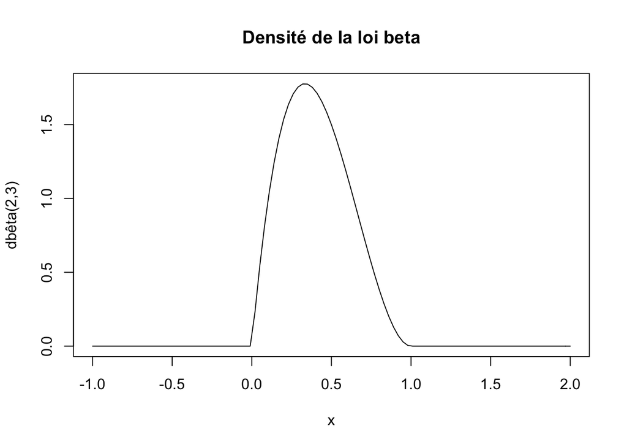

D’aprés le courbe obtenue on propose d’utiliser un modèle melange avec densité unimodale dissymétrique.

Après la simulation nous obtenons le graphe suivant:

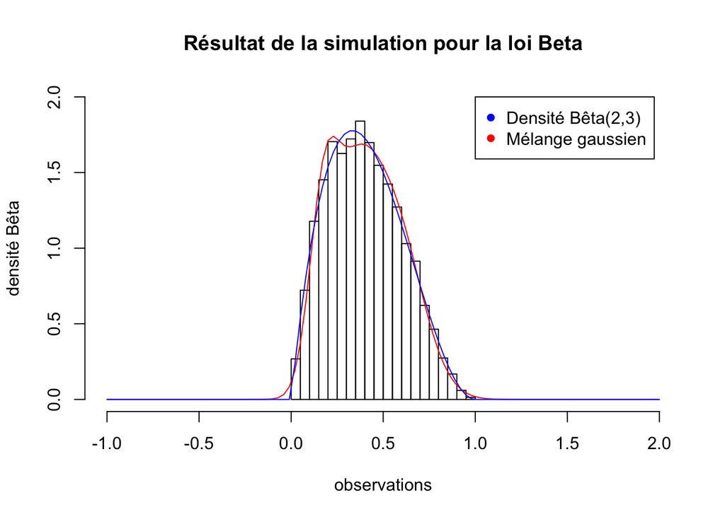

On remaque que ce modèle est plutôt approprié.

#### Loi Gamma

Nous allons proceder de la même manière pour la loi Gamma :

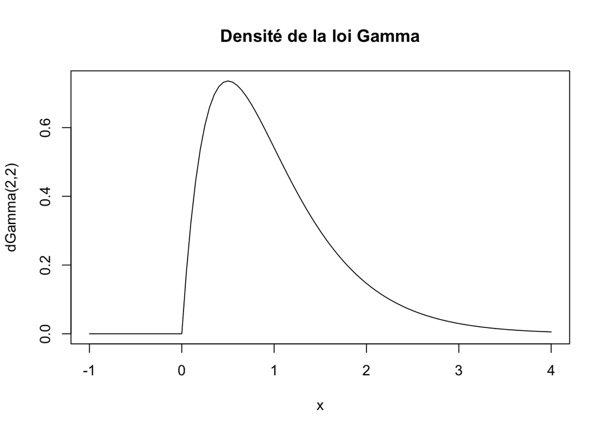

Ici aussi on choisit un modèle de densité unimodale dissymetrique:

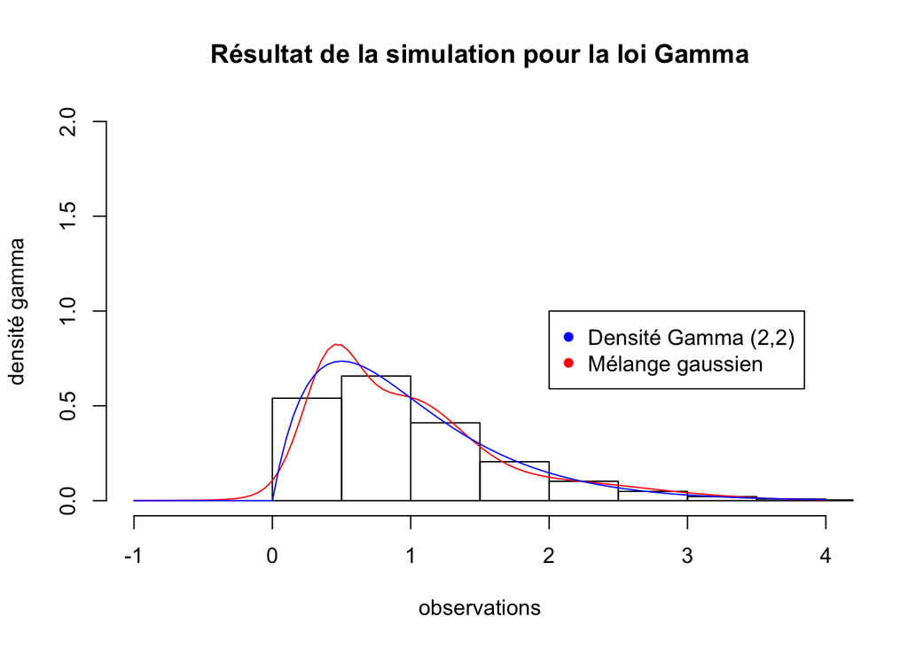

Le modèle utilisé estime assez bien les données.